# Genetic_load_figures_Ppinaster_study

## 4.1 Ratio of total load by dividing with the total number of neutral mutations

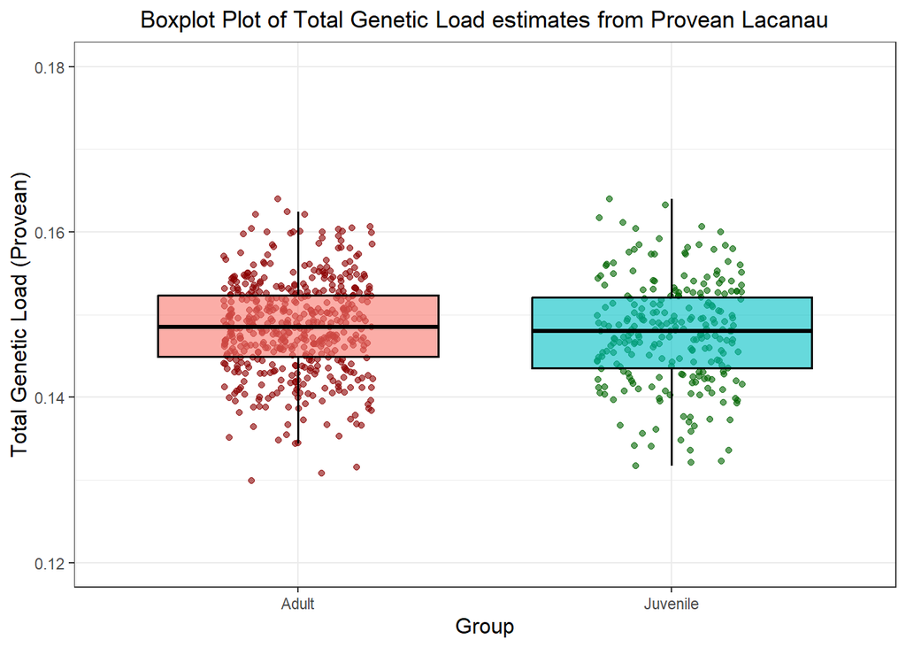

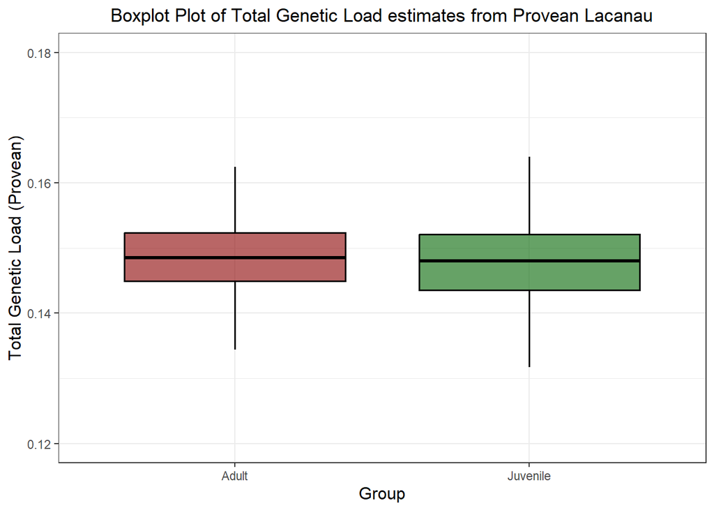

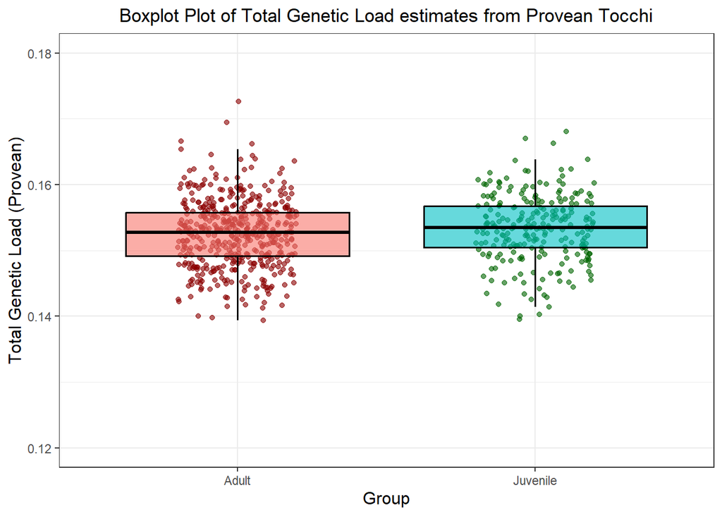

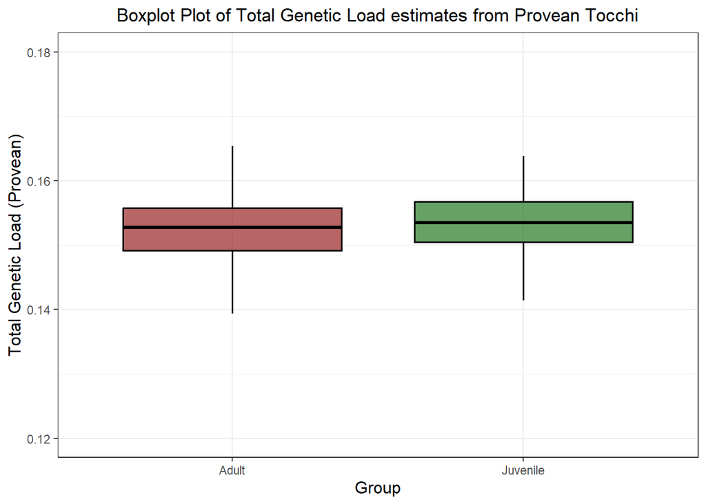

```r
list_plots <- c("Lacanau","Tocchi")

for(x in 1:length(list_plots)){

  plot <- list_plots[x]
  df_total_load <- get(paste0("Df_load_total_realised_",plot))

  t_test_result <- t.test(Total_.allele_counts._GLt ~ Group, data = df_total_load)

    assign(paste0("total_load_difference_across_adults_juv_",plot),t_test_result)

  #Plot
total_load_boxplot <- ggplot(df_total_load, aes(x = Group, y = Total_.allele_counts._GLt, fill = Group)) +
  geom_jitter(aes(color = Group), width = 0.2, alpha = 0.6, size = 1.5, show.legend = FALSE) +
  geom_boxplot(outlier.shape = NA, alpha = 0.6, color = "black", size = 0.6) +
  scale_color_manual(values = c("darkred", "darkgreen")) +
  labs(
    title = paste0("Boxplot Plot of Total Genetic Load estimates from Provean ", plot),
   #x = "Group-age",
    y = "Total Genetic Load (Provean)"
  ) +
  coord_cartesian(ylim = c(0.12, 0.18)) +
  scale_y_continuous(breaks = seq(0.12, 0.18, by = 0.02)) +
  theme_bw() +
  theme(
    plot.title = element_text(hjust = 0.5),
    legend.position = "none",
    axis.text.x = element_text(angle = 0, hjust = 0.5),
    axis.title.x = element_text(size = 12),
    axis.title.y = element_text(size = 12)
  )

plot(total_load_boxplot)

pdf(paste0("Results/Chapter3/Pinaster/Genetic_load_new_estimates/Comparison_adults_juveniles/Total/figures/GL_total_boxplot_",plot,".pdf"), width = 8, height = 6)
print(total_load_boxplot)
dev.off()

total_load_boxplot_wo_points <- ggplot(df_total_load, aes(x = Group, y = Total_.allele_counts._GLt, fill = Group)) +
  #geom_jitter(aes(color = Group), width = 0.2, alpha = 0.6, size = 1.5, show.legend = FALSE) + #points
  geom_boxplot(outlier.shape = NA, alpha = 0.6, color = "black", size = 0.6) +
  scale_fill_manual(values = c("darkred", "darkgreen")) +
  scale_color_manual(values = c("darkred", "darkgreen")) +
  labs(
    title = paste0("Boxplot Plot of Total Genetic Load estimates from Provean ", plot),
    #x = "Group-age",
    y = "Total Genetic Load (Provean)"
  ) +
  coord_cartesian(ylim = c(0.12, 0.18)) +
  scale_y_continuous(breaks = seq(0.12, 0.18, by = 0.02)) +
  theme_bw() +
  theme(
    plot.title = element_text(hjust = 0.5),
    legend.position = "none",
    axis.text.x = element_text(angle = 0, hjust = 0.5),
    axis.title.x = element_text(size = 12),
    axis.title.y = element_text(size = 12)
  )

plot(total_load_boxplot_wo_points)

pdf(paste0("Results/Chapter3/Pinaster/Genetic_load_new_estimates/Comparison_adults_juveniles/Total/figures/GL_total_boxplot_wopoints_",plot,".pdf"), width = 8, height = 6)
print(total_load_boxplot_wo_points)
dev.off()
}
```

```r
print(total_load_difference_across_adults_juv_Lacanau)
```

```
##
##  Welch Two Sample t-test
##
## data:  Total_.allele_counts._GLt by Group
## t = 1.4855, df = 453.11, p-value = 0.1381
## alternative hypothesis: true difference in means between group Adult and group Juvenile is not equal to 0
## 95 percent confidence interval:
##  -0.0002246011  0.0016156258
## sample estimates:
##    mean in group Adult mean in group Juvenile
##              0.1484196              0.1477241
```

```r
print(total_load_difference_across_adults_juv_Tocchi)
```

```
##
##  Welch Two Sample t-test
##
## data:  Total_.allele_counts._GLt by Group
## t = -1.9556, df = 501.78, p-value = 0.05107
## alternative hypothesis: true difference in means between group Adult and group Juvenile is not equal to 0
## 95 percent confidence interval:
##  -1.540632e-03  3.582218e-06
## sample estimates:
##    mean in group Adult mean in group Juvenile
##              0.1525393              0.1533078
```

## 4.2 Number of total deleterious mutations

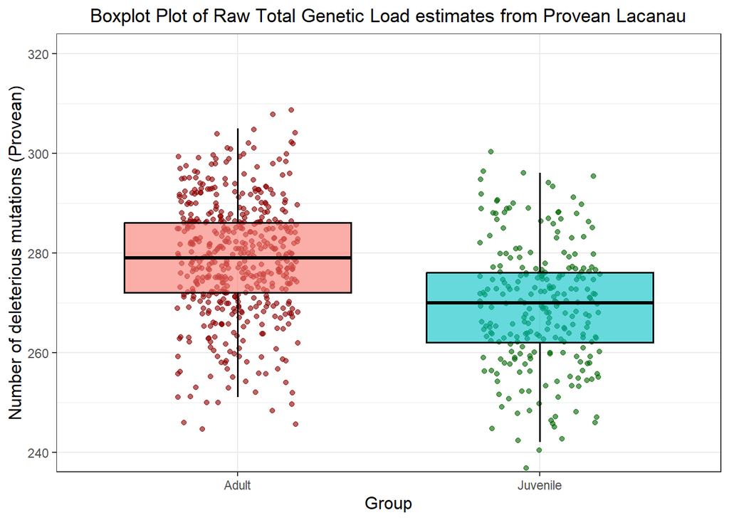

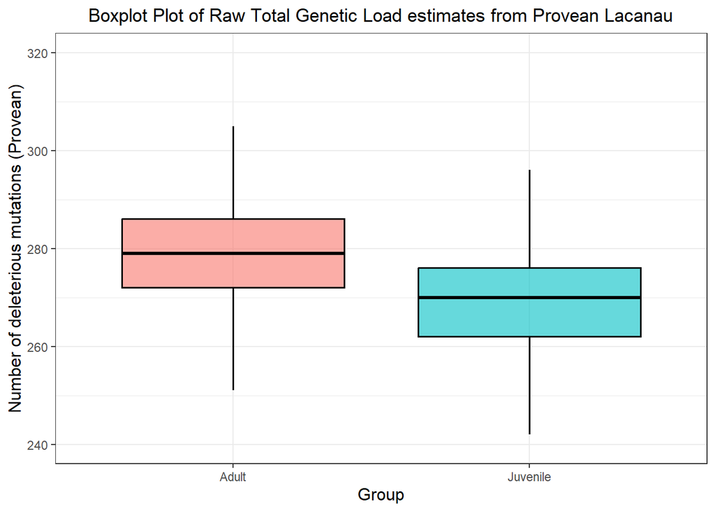

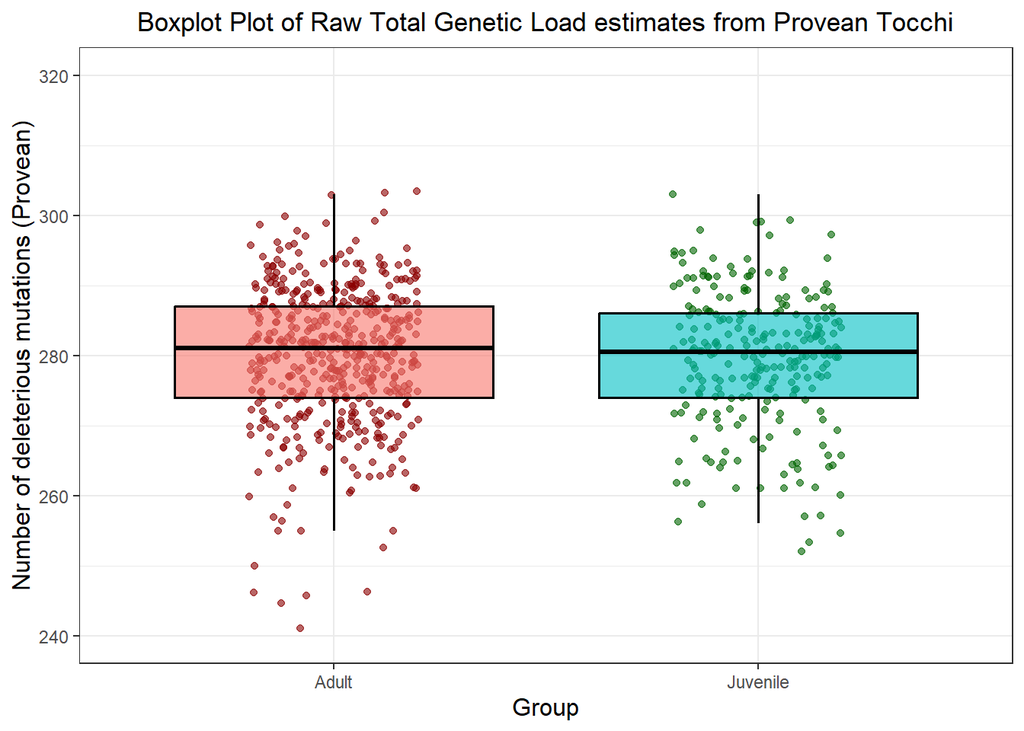

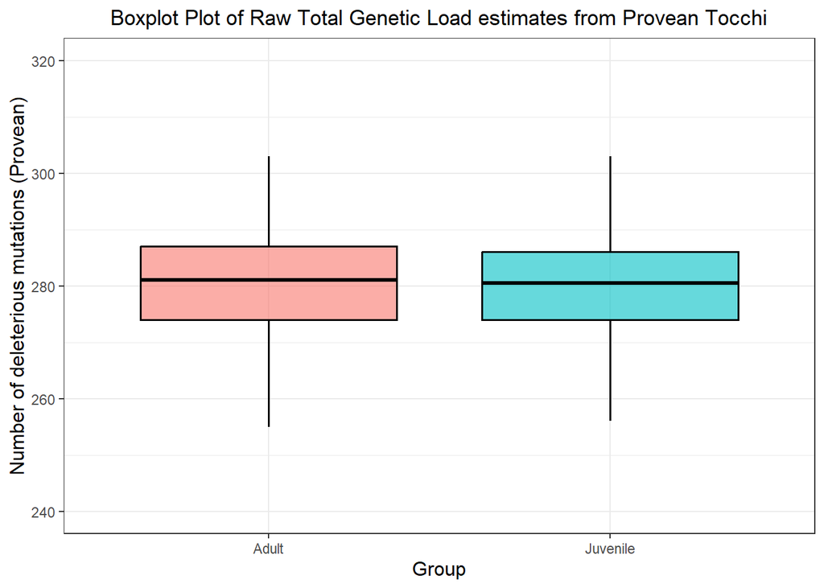

```r
list_plots <- c("Lacanau","Tocchi")

for(x in 1:length(list_plots)){

  plot <- list_plots[x]
  df_total_load <- get(paste0("Df_load_total_realised_",plot))

  t_test_result <- t.test(Allele_deleterious_counts ~ Group, data = df_total_load)

    assign(paste0("raw_total_load_difference_across_adults_juv_",plot),t_test_result)

  #Plot
raw_total_load_boxplot <- ggplot(df_total_load, aes(x = Group, y = Allele_deleterious_counts, fill = Group)) +
  geom_jitter(aes(color = Group), width = 0.2, alpha = 0.6, size = 1.5, show.legend = FALSE) +
  geom_boxplot(outlier.shape = NA, alpha = 0.6, color = "black", size = 0.6) +
  scale_color_manual(values = c("darkred", "darkgreen")) +
  labs(
    title = paste0("Boxplot Plot of Raw Total Genetic Load estimates from Provean ", plot),
    #x = "Group-age",
    y = "Number of deleterious mutations (Provean)"
  ) +
  coord_cartesian(ylim = c(240, 320)) +
  scale_y_continuous(breaks = seq(240, 320, by = 20)) +
  theme_bw() +
  theme(
    plot.title = element_text(hjust = 0.5),
    legend.position = "none",
    axis.text.x = element_text(angle = 0, hjust = 0.5),
    axis.title.x = element_text(size = 12),
    axis.title.y = element_text(size = 12)
  )

plot(raw_total_load_boxplot)

pdf(paste0("Results/Chapter3/Pinaster/Genetic_load_new_estimates/Comparison_adults_juveniles/Total/figures/GL_raw_total_boxplot_",plot,".pdf"), width = 8, height = 6)
print(raw_total_load_boxplot)
dev.off()

raw_total_load_boxplot_wo_points <- ggplot(df_total_load, aes(x = Group, y = Allele_deleterious_counts, fill = Group)) +
  #geom_jitter(aes(color = Group), width = 0.2, alpha = 0.6, size = 1.5, show.legend = FALSE) + #points
  geom_boxplot(outlier.shape = NA, alpha = 0.6, color = "black", size = 0.6) +
  scale_color_manual(values = c("darkred", "darkgreen")) +
  labs(
    title = paste0("Boxplot Plot of Raw Total Genetic Load estimates from Provean ", plot),
    #x = "Group-age",
    y = "Number of deleterious mutations (Provean)"
  ) +
  coord_cartesian(ylim = c(240, 320)) +
  scale_y_continuous(breaks = seq(240, 320, by = 20)) +
  theme_bw() +
  theme(
    plot.title = element_text(hjust = 0.5),
    legend.position = "none",
    axis.text.x = element_text(angle = 0, hjust = 0.5),
    axis.title.x = element_text(size = 12),
    axis.title.y = element_text(size = 12)
  )

plot(raw_total_load_boxplot_wo_points)

pdf(paste0("Results/Chapter3/Pinaster/Genetic_load_new_estimates/Comparison_adults_juveniles/Total/figures/GL_raw_total_boxplot_wopoints_",plot,".pdf"), width = 8, height = 6)
print(raw_total_load_boxplot_wo_points)
dev.off()
}
```

```r
print(raw_total_load_difference_across_adults_juv_Lacanau)
```

```
##
##  Welch Two Sample t-test
##
## data:  Allele_deleterious_counts by Group
## t = 10.254, df = 477.78, p-value < 2.2e-16
## alternative hypothesis: true difference in means between group Adult and group Juvenile is not equal to 0
## 95 percent confidence interval:
##   7.638322 11.259718
## sample estimates:
##    mean in group Adult mean in group Juvenile
##                278.694                269.245
```

```r
print(raw_total_load_difference_across_adults_juv_Tocchi)
```

```
##
##  Welch Two Sample t-test
##
## data:  Allele_deleterious_counts by Group
## t = 0.52931, df = 510.27, p-value = 0.5968
## alternative hypothesis: true difference in means between group Adult and group Juvenile is not equal to 0
## 95 percent confidence interval:
##  -1.075988  1.869576
## sample estimates:
##    mean in group Adult mean in group Juvenile
##               279.9008               279.5040
```

# 5 Potential load

## 5.1 Ratio of potential load by dividing with the number of neutral heterozygous mutations

Potential load correspond to the number of deleterious mutations in heterozygous to the number of neutral mutations in heterozygous.

GLpot = (total number of deleterious mutations – 2 × number of homozygous deleterious mutations)/(total number of neutral mutations – 2 × number of homozygous neutral mutations).

```r
list_plots <- c("Lacanau","Tocchi")

for(x in 1:length(list_plots)){

  plot <- list_plots[x]
  df_potential_load <- get(paste0("Df_load_total_realised_",plot))

df_potential_load$Number_hetero_mut_GLp <- df_potential_load$Allele_neutral_counts - (2*df_potential_load$Homozygous_.neutral_counts)

df_potential_load$Number_hetero_deleterious_mut_GLp <- df_potential_load$Allele_deleterious_counts - (2*df_potential_load$Homozygous_deleterious_counts)

df_potential_load$Provean_GLp_Ppinaster_Set2 <- df_potential_load$Number_hetero_deleterious_mut_GLp / (df_potential_load$Number_hetero_mut_GLp)

assign(paste0("Df_load_total_realised_",plot),df_potential_load)
}
```

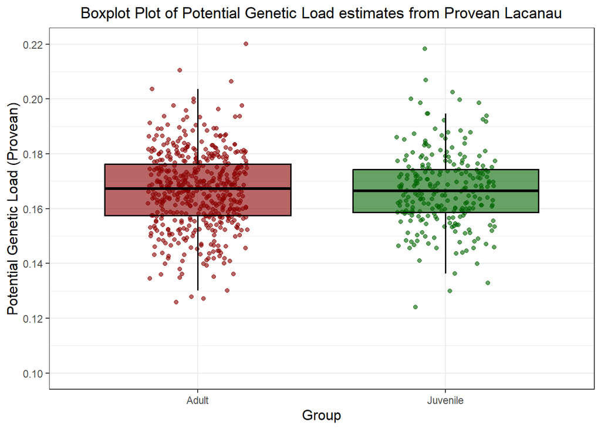

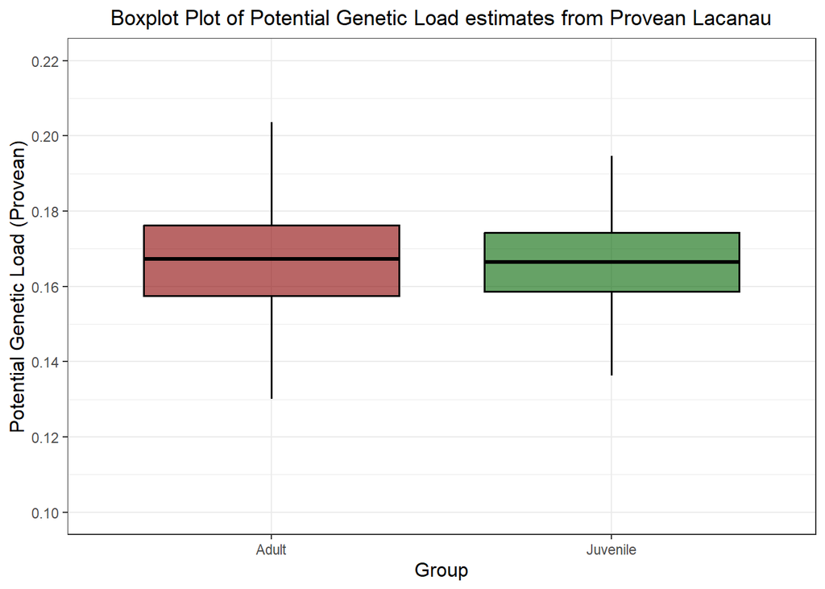

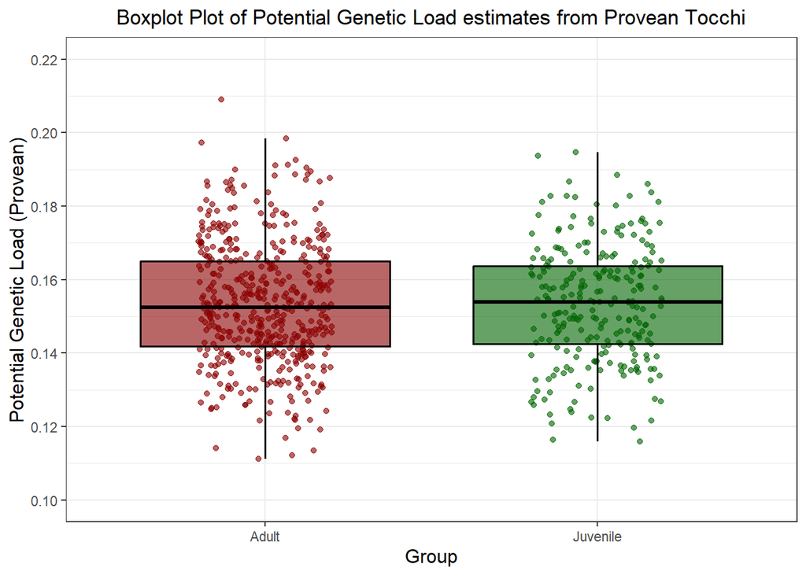

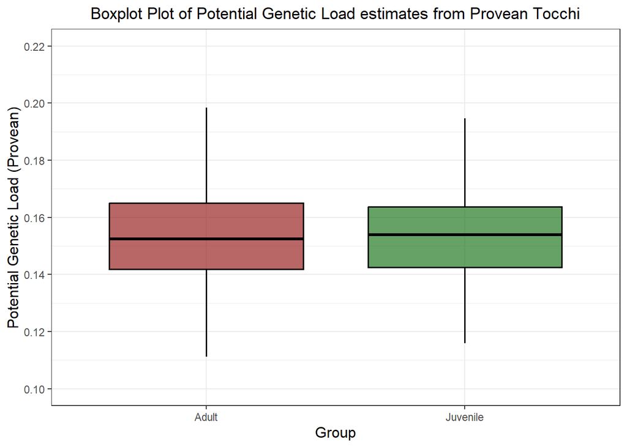

```r
list_plots <- c("Lacanau","Tocchi")

for(x in 1:length(list_plots)){

  plot <- list_plots[x]
  df_potential_load <- get(paste0("Df_load_total_realised_",plot))

  t_test_result <- t.test(Provean_GLp_Ppinaster_Set2 ~ Group, data = df_potential_load)

    assign(paste0("potential_load_difference_across_adults_juv_",plot),t_test_result)

  #plot
potential_load_boxplot <- ggplot(df_potential_load, aes(x = Group, y = Masked_GLm, fill = Group)) +
  geom_jitter(aes(color = Group), width = 0.2, alpha = 0.6, size = 1.5, show.legend = FALSE) +
  geom_boxplot(outlier.shape = NA, alpha = 0.6, color = "black", size = 0.6) +
  scale_fill_manual(values = c("darkred", "darkgreen")) +
  scale_color_manual(values = c("darkred", "darkgreen")) +
  labs(
    title = paste0("Boxplot Plot of Potential Genetic Load estimates from Provean ", plot),
    #x = "Group-age",
    y = "Potential Genetic Load (Provean)"
  ) +
  coord_cartesian(ylim = c(0.10, 0.22)) +
  scale_y_continuous(breaks = seq(0.10, 0.22, by = 0.02)) +
  theme_bw() +
  theme(
    plot.title = element_text(hjust = 0.5),
    legend.position = "none",
    axis.text.x = element_text(angle = 0, hjust = 0.5),
    axis.title.x = element_text(size = 12),
    axis.title.y = element_text(size = 12)
  )

plot(potential_load_boxplot)

pdf(paste0("Results/Chapter3/Pinaster/Genetic_load_new_estimates/Comparison_adults_juveniles/Potential/figures/GL_potential_boxplot_",plot,".pdf"), width = 8, height = 6)
print(potential_load_boxplot)
dev.off()

potential_load_boxplot_wo_points <- ggplot(df_potential_load, aes(x = Group, y = Masked_GLm, fill = Group)) +
  #geom_jitter(aes(color = Group), width = 0.2, alpha = 0.6, size = 1.5, show.legend = FALSE) + #points
  geom_boxplot(outlier.shape = NA, alpha = 0.6, color = "black", size = 0.6) +
  scale_fill_manual(values = c("darkred", "darkgreen")) +
  scale_color_manual(values = c("darkred", "darkgreen")) +
  labs(
    title = paste0("Boxplot Plot of Potential Genetic Load estimates from Provean ", plot),
    #x = "Group-age",
    y = "Potential Genetic Load (Provean)"
  ) +
  coord_cartesian(ylim = c(0.10, 0.22)) +
  scale_y_continuous(breaks = seq(0.10, 0.22, by = 0.02)) +
  theme_bw() +
  theme(
    plot.title = element_text(hjust = 0.5),
    legend.position = "none",
    axis.text.x = element_text(angle = 0, hjust = 0.5),
    axis.title.x = element_text(size = 12),
    axis.title.y = element_text(size = 12)
  )

plot(potential_load_boxplot_wo_points)

pdf(paste0("Results/Chapter3/Pinaster/Genetic_load_new_estimates/Comparison_adults_juveniles/Potential/figures/GL_potential_boxplot_wopoints_",plot,".pdf"), width = 8, height = 6)
print(potential_load_boxplot_wo_points)
dev.off()
}
```

```r
print(potential_load_difference_across_adults_juv_Lacanau)
```

```
##
##  Welch Two Sample t-test
##
## data:  Provean_GLp_Ppinaster_Set2 by Group
## t = -0.05688, df = 502.69, p-value = 0.9547
## alternative hypothesis: true difference in means between group Adult and group Juvenile is not equal to 0
## 95 percent confidence interval:
##  -0.002159413  0.002037896
## sample estimates:
##    mean in group Adult mean in group Juvenile
##              0.1667386              0.1667994
```

```r
print(potential_load_difference_across_adults_juv_Tocchi)
```

```
##
##  Welch Two Sample t-test
##
## data:  Provean_GLp_Ppinaster_Set2 by Group
## t = 0.050194, df = 518.49, p-value = 0.96
## alternative hypothesis: true difference in means between group Adult and group Juvenile is not equal to 0
## 95 percent confidence interval:
##  -0.002407633  0.002533890
## sample estimates:
##    mean in group Adult mean in group Juvenile
##              0.1533509              0.1532878
```

## 5.2 Raw number of deleterious mutations in heterozygous

We computed the potential load without normalising by the number of neutral heterozygous sites because comparisons were performed among individuals within the same population, which are expected to share a common demographic history and similar levels of neutral genetic variation.

Final figure

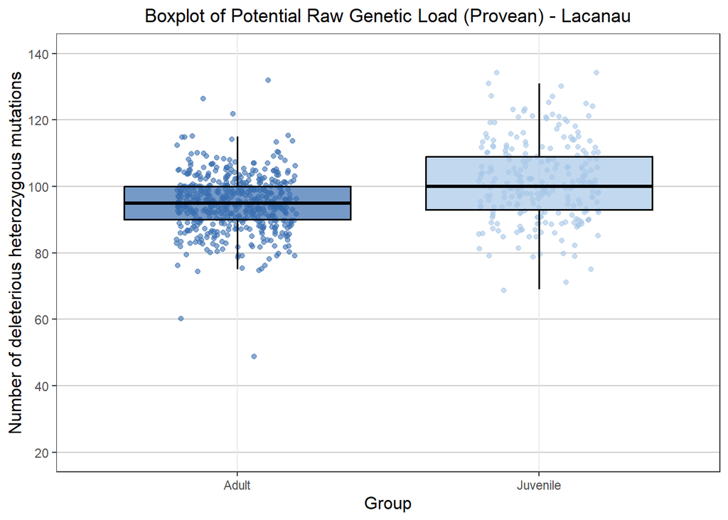

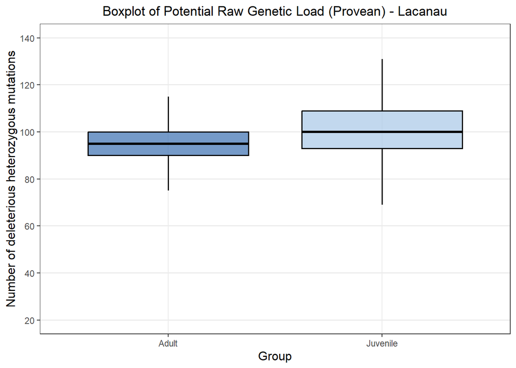

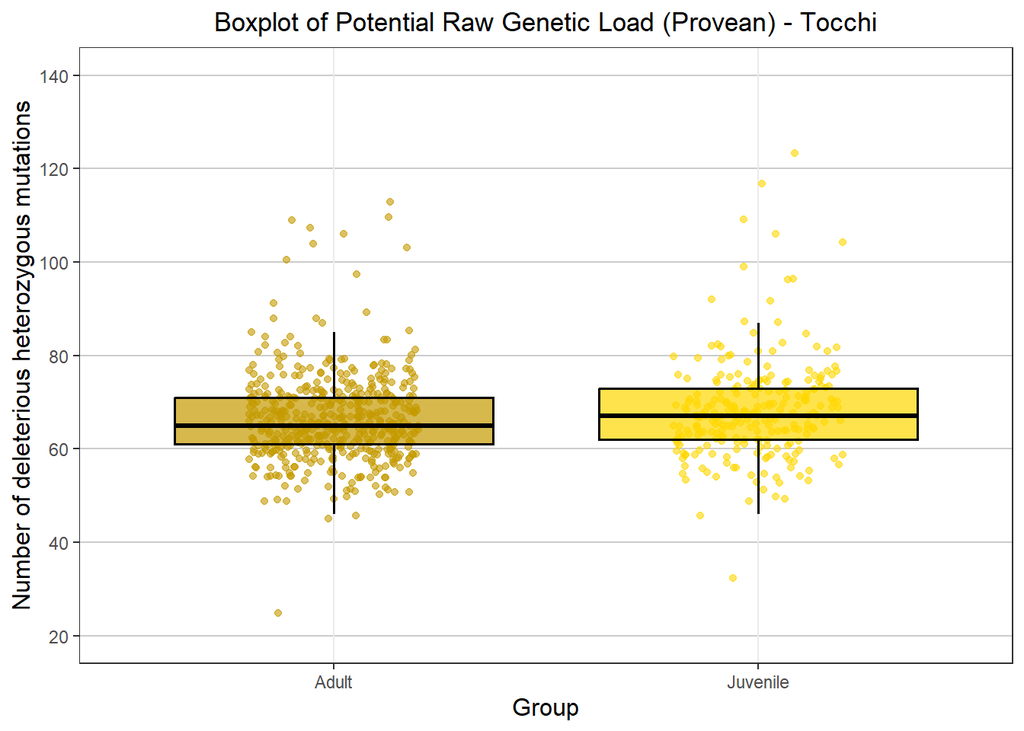

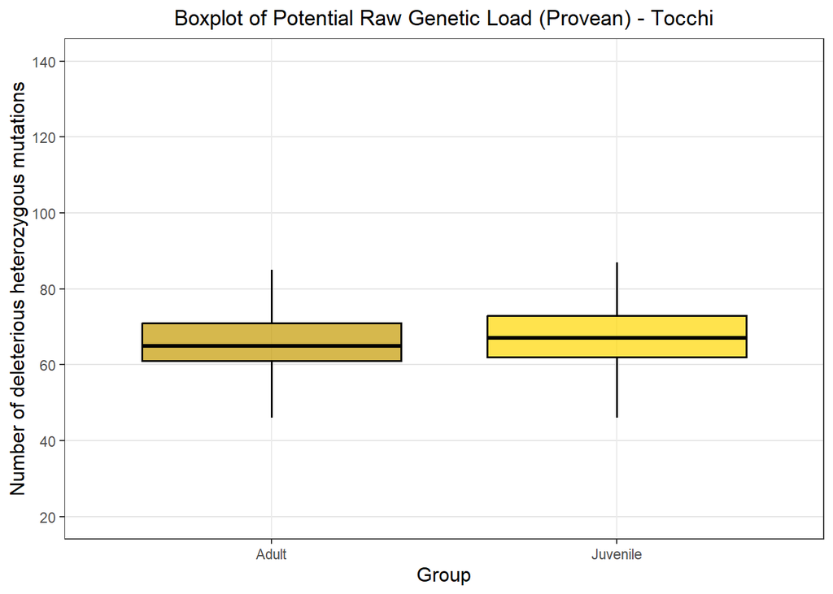

```r
list_plots <- c("Lacanau","Tocchi")

#Define color lists
color_list <- list(
  Lacanau = c(
    Adult = "#3A6FB0",
    Juvenile = "#A7C7E7"
  ),
  Tocchi = c(
    Adult = "#C49A00",
    Juvenile = "#FFD700"
  )
)

for(x in 1:length(list_plots)){

  plot <- list_plots[x]
  df_potential_load <- get(paste0("Df_load_total_realised_",plot))

  t_test_result <- t.test(Heterozygous_deleterious_counts ~ Group, data = df_potential_load)

    assign(paste0("raw_potential_load_difference_across_adults_juv_",plot),t_test_result)

  #Select correct color palette
  col_pal <- color_list[[plot]]

  #Boxplot
  raw_potential_load_boxplot <- ggplot(df_potential_load,
                                       aes(x = Group,
                                           y = Heterozygous_deleterious_counts,
                                           fill = Group)) +
    geom_jitter(aes(color = Group), width = 0.2, alpha = 0.6, size = 1.5, show.legend = FALSE) +
    geom_boxplot(outlier.shape = NA, alpha = 0.7, color = "black", size = 0.6) +
    scale_fill_manual(values = col_pal) +
    scale_color_manual(values = col_pal) +
    labs(
      title = paste0("Boxplot of Potential Raw Genetic Load (Provean) - ", plot),
      y = "Number of deleterious heterozygous mutations"
    ) +
    coord_cartesian(ylim = c(20, 140)) +
  scale_y_continuous(breaks = seq(20, 140, by = 20)) +
    theme_bw() +
theme(
  panel.grid.minor.y = element_blank(),
  panel.grid.minor.x = element_blank(),
  panel.grid.major.y = element_line(color="grey80"),
  plot.title = element_text(hjust = 0.5),
  legend.position = "none",
  axis.text.x = element_text(angle = 0, hjust = 0.5),
  axis.title.x = element_text(size = 12),
  axis.title.y = element_text(size = 12)
)

  plot(raw_potential_load_boxplot)

  #Save plot
  pdf(paste0("Results/Chapter3/Pinaster/Genetic_load_new_estimates/Comparison_adults_juveniles/Potential/figures/GL_raw_potential_boxplot_",plot,".pdf"),
      width = 8, height = 6)
  print(raw_potential_load_boxplot)
  dev.off()

  #Boxplot without the points
  raw_potential_load_boxplot_wo_points <- ggplot(df_potential_load,
                                                 aes(x = Group,
                                                     y = Heterozygous_deleterious_counts,
                                                     fill = Group)) +
    geom_boxplot(outlier.shape = NA, alpha = 0.7, color = "black", size = 0.6) +
    scale_fill_manual(values = col_pal) +
    labs(
      title = paste0("Boxplot of Potential Raw Genetic Load (Provean) - ", plot),
      y = "Number of deleterious heterozygous mutations"
    ) +
    coord_cartesian(ylim = c(20, 140)) +
  scale_y_continuous(breaks = seq(20, 140, by = 20)) +
    theme_bw() +
theme(
  panel.grid.minor.y = element_blank(),
  panel.grid.minor.x = element_blank(),
  panel.grid.major.y = element_line(color="grey90"),
  plot.title = element_text(hjust = 0.5),
  legend.position = "none",
  axis.text.x = element_text(angle = 0, hjust = 0.5),
  axis.title.x = element_text(size = 12),
  axis.title.y = element_text(size = 12)
)

  plot(raw_potential_load_boxplot_wo_points)

  #Save plot without points
  pdf(paste0("Results/Chapter3/Pinaster/Genetic_load_new_estimates/Comparison_adults_juveniles/Potential/figures/GL_raw_potential_boxplot_wopoints_",plot,".pdf"),
      width = 8, height = 6)
  print(raw_potential_load_boxplot_wo_points)
  dev.off()
}
```

```r
#Print t-test results
print(raw_potential_load_difference_across_adults_juv_Lacanau)
```

```
##
##  Welch Two Sample t-test
##
## data:  Heterozygous_deleterious_counts by Group
## t = -7.6481, df = 376.2, p-value = 1.724e-13
## alternative hypothesis: true difference in means between group Adult and group Juvenile is not equal to 0
## 95 percent confidence interval:
##  -8.044740 -4.754184
## sample estimates:
##    mean in group Adult mean in group Juvenile
##                94.9660               101.3655
```

```r
print(raw_potential_load_difference_across_adults_juv_Tocchi)
```

```
##
##  Welch Two Sample t-test
##
## data:  Heterozygous_deleterious_counts by Group
## t = -2.3045, df = 447.77, p-value = 0.02165
## alternative hypothesis: true difference in means between group Adult and group Juvenile is not equal to 0
## 95 percent confidence interval:
##  -3.4838970 -0.2767668
## sample estimates:
##    mean in group Adult mean in group Juvenile
##               66.44628               68.32661
```

Both populations in the same figure

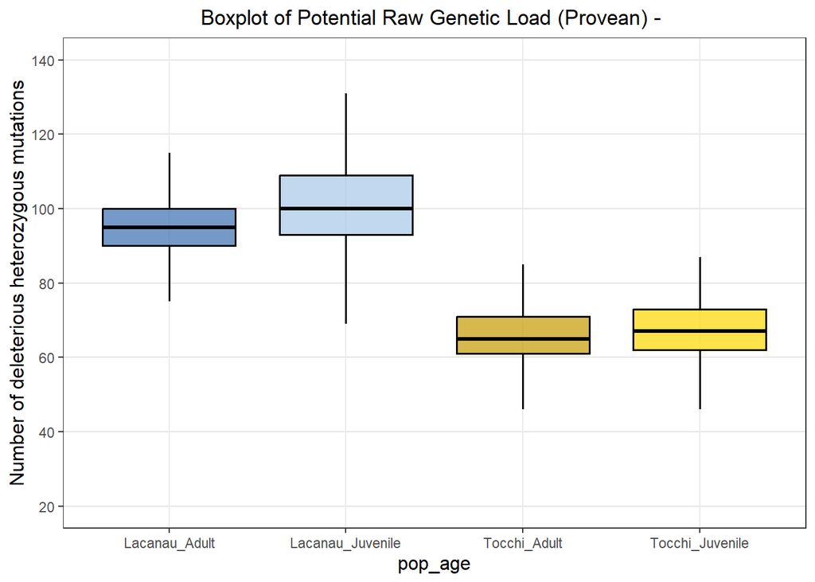

```r
#Merge the two datasets and create a new combined category
df_all <- rbind(
  transform(Df_load_total_realised_Lacanau, population = "Lacanau"),
  transform(Df_load_total_realised_Tocchi, population = "Tocchi")
)

#Create combined factor for x-axis: Population + Age
df_all$pop_age <- factor(
  paste(df_all$population, df_all$Group, sep = "_"),
  levels = c("Lacanau_Adult","Lacanau_Juvenile",
             "Tocchi_Adult","Tocchi_Juvenile")
)

#Colors:
custom_colors <- c(
  "Lacanau_Adult"     = "#3A6FB0",
   "Lacanau_Juvenile" = "#A7C7E7",
  "Tocchi_Adult"      = "#C49A00",
    "Tocchi_Juvenile"  = "#FFD700"
)

legend_colors <- c(
  "Lacanau" = "#3A6FB0",
  "Tocchi"  = "#E6C300"
)

raw_potential_load_boxplot_wo_points_combined <- ggplot(df_all, aes(x = pop_age, y = Heterozygous_deleterious_counts, fill = pop_age)) +
  geom_boxplot(outlier.shape = NA, alpha = 0.7, color = "black", size = 0.6) +
    scale_fill_manual(values = custom_colors) +
    labs(
      title = "Boxplot of Potential Raw Genetic Load (Provean) - ",
      y = "Number of deleterious heterozygous mutations"
    ) +
    coord_cartesian(ylim = c(20, 140)) +
    scale_y_continuous(breaks = seq(20, 140, by = 20)) +
    theme_bw() +
      theme_bw() +
theme(
  panel.grid.minor.y = element_blank(),
  panel.grid.minor.x = element_blank(),
  panel.grid.major.y = element_line(color="grey90"),
  plot.title = element_text(hjust = 0.5),
  legend.position = "none",
  axis.text.x = element_text(angle = 0, hjust = 0.5),
  axis.title.x = element_text(size = 12),
  axis.title.y = element_text(size = 12)
)

  plot(raw_potential_load_boxplot_wo_points_combined)
```

```r
  #Save plot without points
  pdf(paste0("Results/Chapter3/Pinaster/Genetic_load_new_estimates/Comparison_adults_juveniles/Potential/figures/GL_raw_potential_boxplot_wopoints_both_plots_",plot,".pdf"),
      width = 8, height = 6)
  print(raw_potential_load_boxplot_wo_points_combined)
  dev.off()
```

```r
#one way anova to see if groups are differents
anova_result_potential_raw <- aov(Heterozygous_deleterious_counts ~ pop_age, data = df_all)
summary(anova_result_potential_raw)
```

```
##               Df Sum Sq Mean Sq F value Pr(>F)
## pop_age        3 340793  113598    1172 <2e-16 ***
## Residuals   1477 143218      97
## ---
## Signif. codes:  0 '***' 0.001 '**' 0.01 '*' 0.05 '.' 0.1 ' ' 1
```

```r
tukey_result <- TukeyHSD(anova_result_potential_raw)
tukey_result
```

```
##   Tukey multiple comparisons of means
##     95% family-wise confidence level
##
## Fit: aov(formula = Heterozygous_deleterious_counts ~ pop_age, data = df_all)
##
## $pop_age
##                                        diff          lwr        upr     p adj
## Lacanau_Juvenile-Lacanau_Adult     6.399462   4.43506508   8.363859 0.0000000
## Tocchi_Adult-Lacanau_Adult       -28.519719 -30.13468300 -26.904755 0.0000000
## Tocchi_Juvenile-Lacanau_Adult    -26.639387 -28.60642593 -24.672348 0.0000000
## Tocchi_Adult-Lacanau_Juvenile    -34.919181 -36.89434235 -32.944019 0.0000000
## Tocchi_Juvenile-Lacanau_Juvenile -33.038849 -35.31093961 -30.766758 0.0000000
## Tocchi_Juvenile-Tocchi_Adult       1.880332  -0.09745727   3.858121 0.0692859
```

```r
anova_result_pop_potential_raw <- aov(Heterozygous_deleterious_counts ~ population, data = df_all)
summary(anova_result_pop_potential_raw)
```

```
##               Df Sum Sq Mean Sq F value Pr(>F)
## population     1 333406  333406    3274 <2e-16 ***
## Residuals   1479 150605     102
## ---
## Signif. codes:  0 '***' 0.001 '**' 0.01 '*' 0.05 '.' 0.1 ' ' 1
```

```r
#Compute median per group
df_all %>% group_by(population) %>% summarise(median = median(Heterozygous_deleterious_counts))
```

```
## # A tibble: 2 × 2
##   population median
##   <chr>       <dbl>
## 1 Lacanau        97
## 2 Tocchi         66
```

```r
#Correlation between potential and realised load
cor(df_all$Homozygous_deleterious_counts,df_all$Heterozygous_deleterious_counts)
```

```
## [1] -0.8853631
```

```r
df_all_lac <- df_all %>% filter(population=="Lacanau")

cor(df_all_lac$Homozygous_deleterious_counts,df_all_lac$Heterozygous_deleterious_counts)
```

```
## [1] -0.694076
```

```r
df_all_toc <- df_all %>% filter(population=="Tocchi")

cor(df_all_toc$Homozygous_deleterious_counts,df_all_toc$Heterozygous_deleterious_counts)
```

```
## [1] -0.7975331
```